# Time series: frequency domain

Frequency domain time series looks at recurring elements. These are e.g. caused by:

- astronomical processes
  - sun: day-night: temperature, tides
  - sun: yearly: phenological, plant physiology
  - moon: tidal variations
- social
  - week, months (?)
- biological:
  - heartbeat
  - blood pressure
  - walking, flying, swimming
- vibration:
  - two flowing media: waves (wind-water), ripples (wind-sand, water-sand)
  - musical instruments
- other
  - anything that turns, or walks

To review: Trigonometry, e.g. http://en.wikipedia.org/wiki/Trigonometry

The angle transformation formula is given here:

$$\sin(A \pm B) = \sin A \cos B \pm \cos A \sin B$$

In case of a function of time $t$, shifted with a phase shift $\phi$:

$$f(t) = sin(t + \phi) = \sin t \cos \phi + \cos t \sin \phi = a \sin t + b \cos t$$

with $a = \cos \phi$ and $b = \sin \phi$

Try the following code:

```r
x = seq(0, 4*pi, length.out = 200) # x plotting range

f = function(dir, x) { # plot the combination of a sin+cos function, based on dir
    a = sin(dir)
    b = cos(dir)
    # three curves:
    plot(a * sin(x) + b * cos(x) ~ x, type = 'l', asp=1, col = 'green')
    lines(x, a * sin(x), col = 'red')
    lines(x, b * cos(x), col = 'blue')
    # legend:
    lines(c(10, 10+a), c(2,2), col = 'red')
    lines(c(10, 10), c(2,2+b), col = 'blue')
    arrows(x0 = 10, x1 = 10+a, y0 = 2, y1 = 2+b, .1, col = 'green')
    title("red: sin(x), blue: cos(x), green: sum")
}

for (d in seq(0, 2*pi, length.out = 100)) {
    f(d, x)
    Sys.sleep(.1) # give us some time to think this over!
}
```

## Local regression: LOWESS, LOESS

Moving (unweighted) average filters, shown in

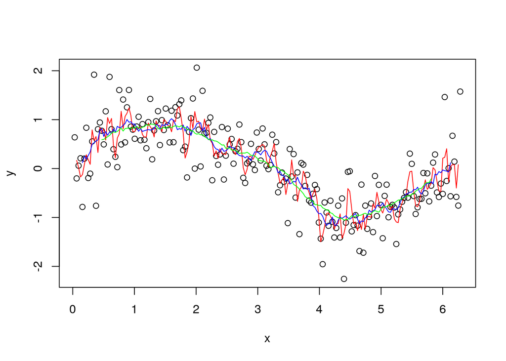

```r
set.seed(13531)
n = 200
x = (1:n)/n * 2 * pi
y = sin(x) + 0.5 * rnorm(n)
plot(x, y)
lines(x, filter(y, rep(1/3, 3)), col='red')
lines(x, filter(y, rep(1/10, 10)), col='blue')
lines(x, filter(y, rep(1/30, 30)), col='green')
```

generate the smooth pattern, but are themselves not smooth: the nearest $n$ observations taken is always a *discrete* process. When we move the filter in a continuous way (along $x$), new points suddenly enter the window, and obtain a positive weight ($1/n$). This causes the moving average to be *discontinuous*.

A continuous, *smooth* function is obtained by assigning non-constant weights such that

- observations, at the edge of entering/exiting the window, have a weight of zero
- (as a consequence:) observations closer to the middle of the window have maximum weight

We can construct such a filter, e.g. by a parabola:

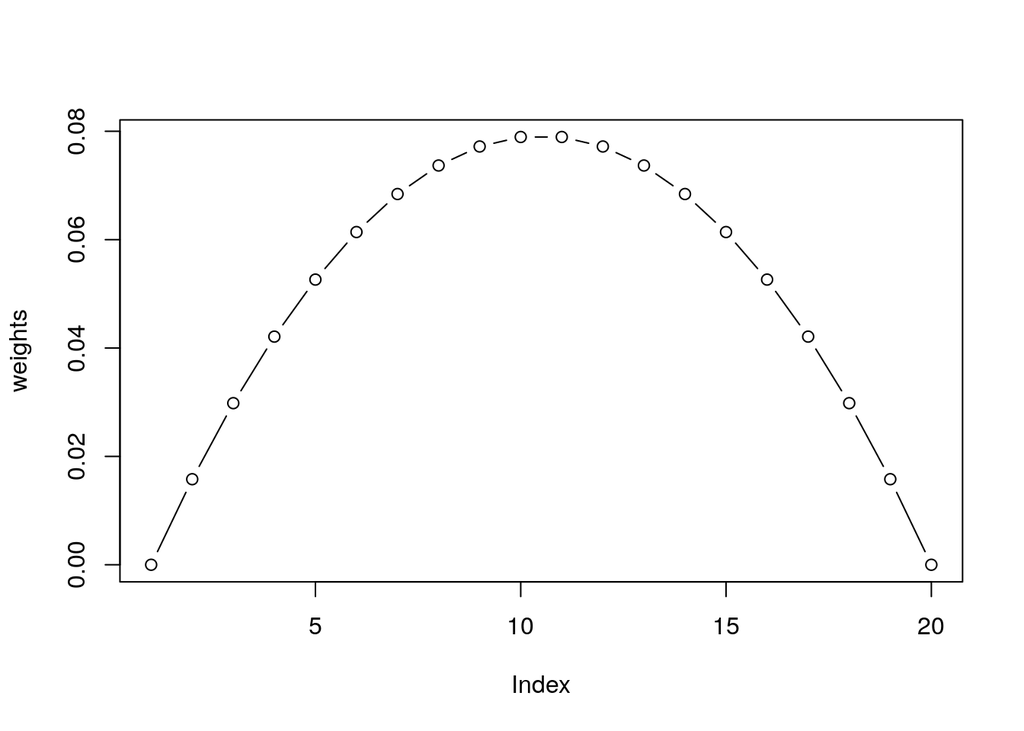

```r
weights = 1 - seq(-1, 1, length.out = 20)^2
weights = weights / sum(weights) # sum to 1
plot(weights, type = 'b')
```

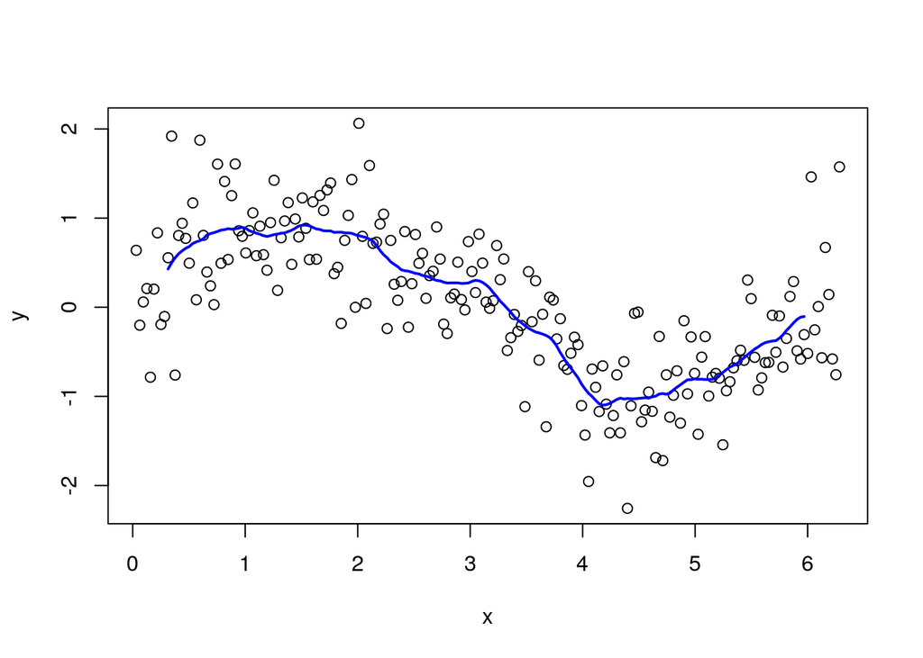

```r
plot(x, y)
lines(x, filter(y, weights), col='blue', lwd = 2)
```

Local regression (LOWESS, LOESS) is an improvement over weighted moving average filters, in that it does not only allow a weighted mean, but also a weighted regression model; in the following plot the lines are shifted vertically by 0.05 and 0.1, because otherwise they would entirely overplot each other:

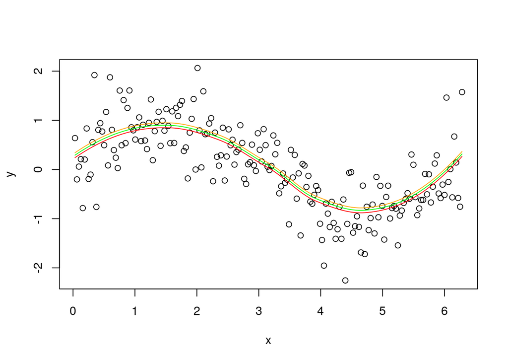

```r
plot(x, y)
lines(x, predict(loess(y ~ x)), col = 'red') # local linear trend
lines(x, .05 + predict(loess(y ~ x + x^2)), col = 'green') # local quadratic trend
lines(x, .10 + predict(loess(y ~ 0 * x)), col = 'orange') # mean
```

We can manipulate the width of the moving window by parameter `span`, e.g.

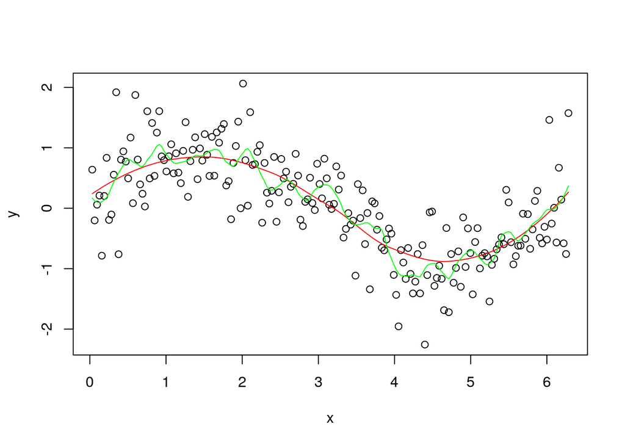

```r
plot(x, y)
lines(x, predict(loess(y ~ x)), col = 'red') # default span: .75
lines(x, predict(loess(y ~ x, span = 0.1)), col = 'green') # narrow window
```

## How to fit a loess to a periodic effect?

*In case we know the period of a periodic effect*, we can transform the $x$ variable to an angle, by
$$2 \pi (x \mod a) * 2 \pi$$
with $a$ the period and mod the remainder of the division (modulo). Next, windows should be computed in angular space, meaning that $2 \pi$ equals 0.

## stl, HoltWinters

stl and HoltWinters are two approaches to fit models to time series that contain a periodic component and a trend:

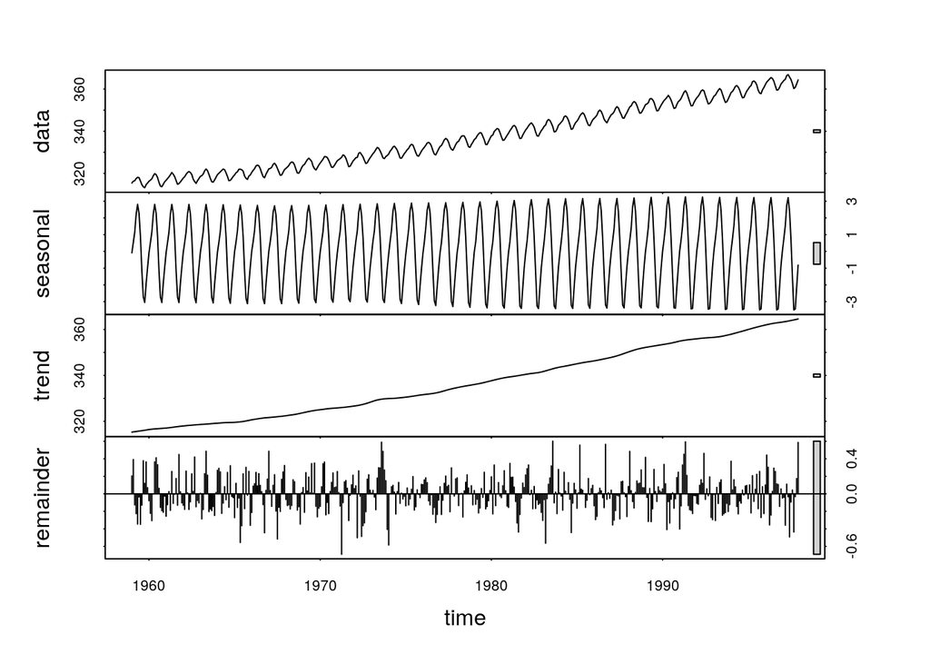

```r
plot(stl(co2, 12))
```

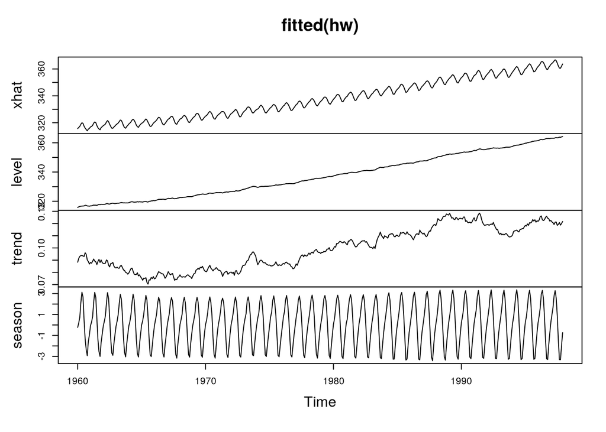

```r
hw = HoltWinters(co2)
plot(fitted(hw))
```

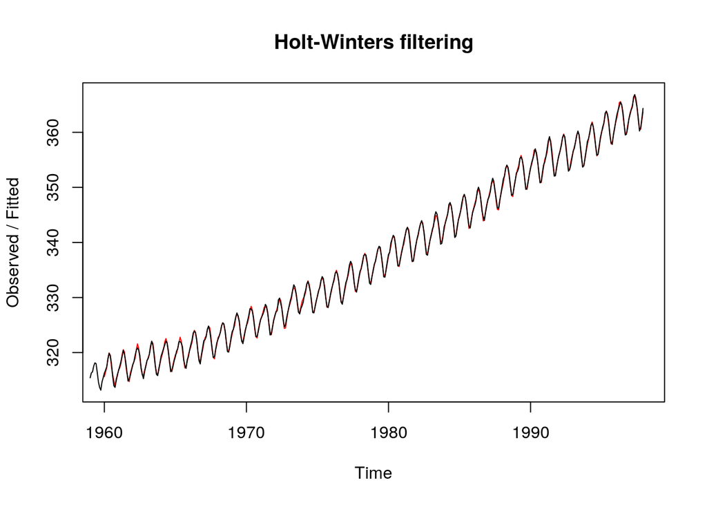

```r
plot(hw)
```

Do read the documentation of both functions, and try to understand what they do.